# Guided Practice

# Loading, setting up

Click the green arrow to the right to run this code chunk.

```r
library(tidyverse)
library(here)
library(janitor)
library(tidykids)

# loading data
d <- read_csv(here("data", "sci-online-classes.csv"))
# making the names easier to read and type
d <- clean_names(d)

# selecting particular variables
d <- d %>%
  select(student_id:gender, time_spent_hours, int, pc, uv)
```

# ——————

# DATA VISUALIZATION

# ——————

# Visualizing a distribution

Change the `final_grade_cems` variable to `time_spent_hours` in the code below and then run this code chunk by clicking the green arrow.

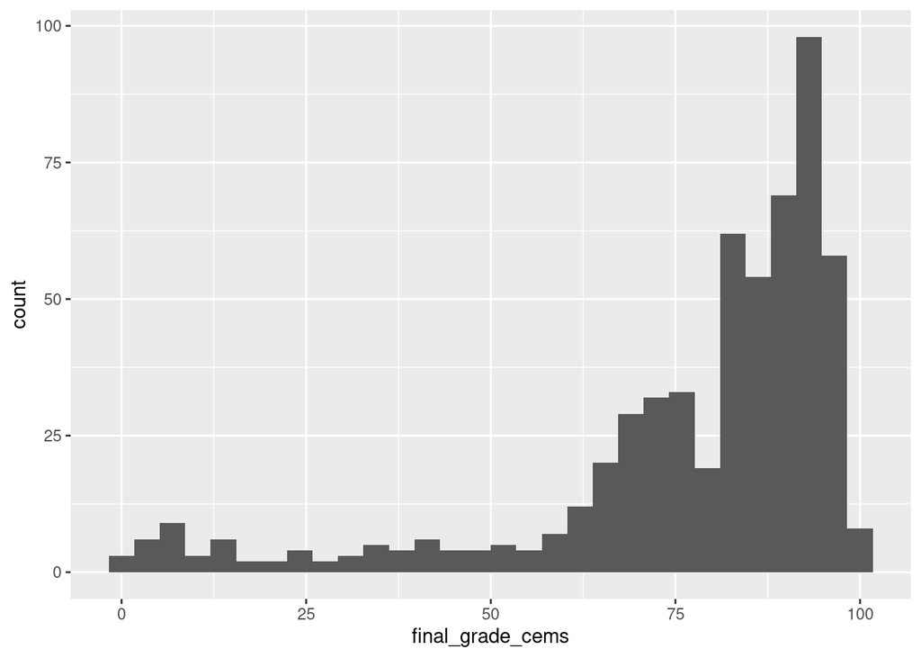

```r
d %>%
  ggplot(aes(x = final_grade_cems)) +
  geom_histogram()
```

Visualize the distribution using a density plot by replacing `geom_histogram()` with `geom_density()` (then, again, run the code below).

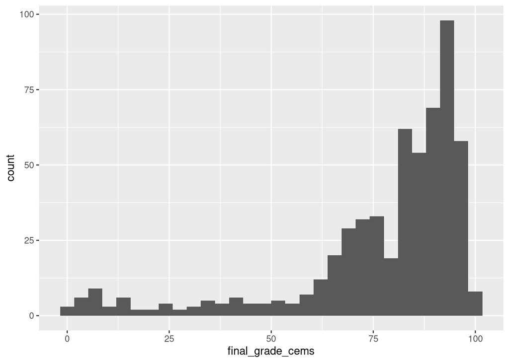

```r
d %>%
  ggplot(aes(x = final_grade_cems)) +
  geom_histogram()
```

# Visualizing a scatter plot and fitted model

The code below visualizes how students’ self-reported *interest in science* relates to their *self-confidence* about their ability in science:

```r
d %>%
  ggplot(aes(x = int, y = pc)) +
  geom_point()
```

[output not shown]

Add a fitted line to the code below with the `geom_smooth()` function we used in the coding together session.

```r
d %>%
  ggplot(aes(x = int, y = pc)) +
  geom_point()
```

[output not shown]

Finally, facet the plot you created in the code chunk above by the subject of the course by adding the `facet_wrap()` line we used in the coding together session:

```r
d %>%
  ggplot(aes(x = int, y = pc)) +
  geom_point()
```

[output not shown]

# ———————

# Qualitative Analysis

# ———————

Let’s run this code chunk to load packages we’ll need and to get setup:

```r
library(tidytext) # note that we've already loaded other packages we will use

# load the text data

td <- read_csv(here("data", "qual-data.csv"))
# making the names easier to read and type
td <- clean_names(td)

# inspect the data

glimpse(td)
```

```
## Rows: 122
## Columns: 2
## $ id       <dbl> 1, 6, 12, 15, 36, 40, 46, 49, 50, 51, 54, 57, 64, 69, 71, 73,…
## $ response <chr> "I felt I could make a difference in children’s lives and tea…
```

Create tokens and remove stop words:

```r
# creating tokens
td <- td %>%
  unnest_tokens(word, response)

# inspect the data
glimpse(td)
```

```
## Rows: 1,995
## Columns: 2
## $ id   <dbl> 1, 1, 1, 1, 1, 1, 1, 1, 1, 1, 1, 1, 1, 1, 6, 6, 6, 6, 6, 6, 6, 6,…
## $ word <chr> "i", "felt", "i", "could", "make", "a", "difference", "in", "chil…
```

```r
# remove stop words
td <- td %>%
  anti_join(stop_words)
```

Lastly, from the 10 most frequent terms, create a column chart using the `geom_col()` line of code we used when coding together in the data visualization session:

```r
td %>%
  count(word, sort = TRUE) %>%
  top_n(10)
```

```
## # A tibble: 11 x 2
##    word           n
##    <chr>      <int>
##  1 children      46
##  2 love          32
##  3 kids          29
##  4 teachers      26
##  5 school        25
##  6 teaching      21
##  7 lives         13
##  8 teacher       13
##  9 difference    12
## 10 enjoyed       12
## 11 students      12
```